# **Grouping, Summarizing, and Plotting Data**

Giorgi Nikolaishvili EC 320: Introduction to Econometrics University of Oregon

Spring 2022

## Recap

What we learned last week:

- Reading and writing `.csv` files
- Absolute vs. relative file paths
- Tidy data
- `select()` – select variables
- `filter()` – select observations
- `mutate()` – create new variables
- `arrange()` – order observations
- `%>%` – piping

## Loading Packages (Review)

Suppose we want to load the `tidyverse` and `gapminder` packages.

An **incorrect** approach:

```r
library(tidyverse)
library(gapminder)
```

Another **incorrect** approach:

```r
library(pacman)
p_load(tidyverse)
p_load(gapminder)
```

The **correct** approach:

```r
library(pacman)
p_load(tidyverse, gapminder)
```

## Pipe Operator `%>%` (Review)

Recall that the pipe operator, `%>%`, passes an object to a function as an input.

An **incorrect** approach to applying multiple functions in succession:

```r
df <- select(mtcars, mpg, wt) # select `mpg` and `wt` columns from mtcars
df <- filter(df, mpg >= 20)   # select observations with `mpg` > or = 20
df <- arrange(df, mpg)        # order observations with respect to `mpg`
```

Another **incorrect** approach:

```r
df <- arrange(filter(select(mtcars, mpg, wt), mpg >= 20), mpg)
```

The **correct** approach using the pipe operator:

```r
df <- mtcars %>%
        select(mpg, wt) %>%     # `select()` receives `mtcars`
        filter(mpg >= 20) %>%   # `filter()` receives `mtcars %>% select()`
        arrange(mpg)            # `arrange()` receives `mtcars %>% select() %>% filter()`
```

## Grouping and Summarizing

As econometricians, we sometimes want to aggregate and produce summary statistics about our data.

Recall the `gapminder` dataset:

```r
head(gapminder)
```

```
## # A tibble: 6 x 6
##   country     continent  year lifeExp      pop gdpPercap
##   <fct>       <fct>     <int>   <dbl>    <int>     <dbl>
## 1 Afghanistan Asia       1952    28.8  8425333      779.
## 2 Afghanistan Asia       1957    30.3  9240934      821.
## 3 Afghanistan Asia       1962    32.0 10267083      853.
## 4 Afghanistan Asia       1967    34.0 11537966      836.
## 5 Afghanistan Asia       1972    36.1 13079460      740.
## 6 Afghanistan Asia       1977    38.4 14880372      786.
```

- What is the average/smallest/greatest life expectancy across all countries over the entire sample period?
- What is the total GDP of the world in the year 1997?
- What is the average/smallest/greatest life expectancy over the entire sample period in each continent?
- What is the average/smallest/greatest life expectancy in each year in each continent?
- What is the total GDP in each year in each continent?

The above questions can be answered with the aid of the `summarize()` and `group_by` functions, available through `tidyverse`.

### `summarize()`

The `summarize()` function takes a dataset as an input, along with instructions on how to summarize the given data and store the indicated summary into a new tibble as a variable (or multiple variables).

Simple example:

```r
gapminder %>%
  summarize(avgLifeExp = mean(lifeExp))
```

```
## # A tibble: 1 x 1
##   avgLifeExp
##        <dbl>
## 1       59.5
```

In the above code chunk, we’ve given `summarize()` a data input of `gapminder`, and then told it to compute the average of the `lifeExp` column using `mean()`, and store the output into a variable called `avgLifeExp`.

Now let’s move on to other questions, and combine `summarize()` with other familiar functions (`filter()`, `select()`, `mutate()`, `arrange()`).

What was the average life expectancy in 1997?

```r
gapminder %>%
  filter(year == 1997) %>%
  summarize(avgLifeExp = mean(lifeExp))
```

```
## # A tibble: 1 x 1
##   avgLifeExp
##        <dbl>
## 1       65.0
```

What was the total GDP of the world in 1997 (in billions of USD)?

```r
gapminder %>%
  filter(year == 1997) %>%
  mutate(gdp = pop * gdpPercap) %>%
  summarize(totGDP = sum(gdp)/(10^9))
```

```
## # A tibble: 1 x 1
##   totGDP
##    <dbl>
## 1 41006.
```

We can answer both of the above questions inside of a single `summarize()` command:

```r
gapminder %>%
  filter(year == 1997) %>%
  mutate(gdp = pop * gdpPercap) %>%
  summarize(avgLifeExp = mean(lifeExp),
            totGDP = sum(gdp)/(10^9))
```

```
## # A tibble: 1 x 2
##   avgLifeExp totGDP
##        <dbl>  <dbl>
## 1       65.0 41006.
```

You can use the following functions inside of `summarize()`:

- `mean()`
- `sum()`
- `median()`
- `min()`
- `max()`

### `group_by()`

The `group_by()` function allows us to group the observations in a dataset into different categories.

For example, in the `gapminder` dataset, we know that each observation is associated with a specific country, located in a specific continent, at a specific point in time.

Therefore, we could partition our data by

1. country (`group_by(country)`)
2. continent (`group_by(continent)`)
3. time (`group_by(year)`)
4. country and time (`group_by(country, year)`)
5. continent and time (`group_by(continent, year)`)

and produce summary statistics for each partition of the data.

Let’s see `group_by()` in action by answering some questions about the `gapminder` data.

What is the total GDP (in billions of USD) of each continent in the year 1997?

```r
gapminder %>%
  filter(year == 1997) %>%
  group_by(continent) %>%                 #
  mutate(gdp = pop * gdpPercap) %>%
  summarize(avgLifeExp = mean(lifeExp),
            totGDP = sum(gdp)/(10^9))
```

```
## # A tibble: 5 x 3
##   continent avgLifeExp totGDP
## * <fct>          <dbl>  <dbl>
## 1 Africa          53.6  1561.
## 2 Americas        71.2 14567.
## 3 Asia            68.0 12791.
## 4 Europe          75.5 11508.
## 5 Oceania         78.2   579.
```

What is the total world GDP (in billions of USD) in each year of the sample?

```r
gapminder %>%
  group_by(year) %>%
  mutate(gdp = pop * gdpPercap) %>%
  summarize(avgLifeExp = mean(lifeExp),
            totGDP = sum(gdp)/(10^9))
```

```
## # A tibble: 12 x 3
##     year avgLifeExp totGDP
##  * <int>      <dbl>  <dbl>
##  1  1952       49.1  7038.
##  2  1957       51.5  8896.
##  3  1962       53.6 11004.
##  4  1967       55.7 14248.
##  5  1972       57.6 18421.
##  6  1977       59.6 22318.
##  7  1982       61.5 25382.
##  8  1987       63.2 30133.
##  9  1992       64.2 34501.
## 10  1997       65.0 41006.
## 11  2002       65.7 47266.
## 12  2007       67.0 58109.
```

What is the total GDP (in billions of USD) of each continent in each year of the sample?

```r
gapminder %>%
  group_by(continent, year) %>%                 #
  mutate(gdp = pop * gdpPercap) %>%
  summarize(avgLifeExp = mean(lifeExp),
            totGDP = sum(gdp)/(10^9))
```

```
## # A tibble: 60 x 4
## # Groups:   continent [5]
##    continent  year avgLifeExp totGDP
##    <fct>     <int>      <dbl>  <dbl>
##  1 Africa     1952       39.1   312.
##  2 Africa     1957       41.3   383.
##  3 Africa     1962       43.3   457.
##  4 Africa     1967       45.3   595.
##  5 Africa     1972       47.5   784.
##  6 Africa     1977       49.6   972.
##  7 Africa     1982       51.6  1146.
##  8 Africa     1987       53.3  1254.
##  9 Africa     1992       53.6  1365.
## 10 Africa     1997       53.6  1561.
## # ... with 50 more rows
```

## Plotting using `ggplot2`

`ggplot2` is a package that lives inside `tidyverse` (`tidyverse` is actually a package that contains a group of packages, each of which contains a group of functions).

`ggplot2` allows us to neatly visualize data!

Many academic researchers and data scientists exclusively use `ggplot2` to make graphs.

Today we will learn the basics of `ggplot2` and work through some examples.

Click [here](https://ggplot2-book.org/index.html) for a wonderful free text on using ggplot.

### Scatter Plots

Suppose I want to focus on `gapminder` data of the year 1997.

```r
data_97_df <- gapminder %>%
            filter(year == 1997)
```

I suspect that GDP per capita and life expectancy are likely to be positive correlated – in other words, higher life expectancy is likely to be associated with higher GDP per capita, and vice versa.

Let’s test this hypothesis non-rigorously by plotting the data in a scatterplot:

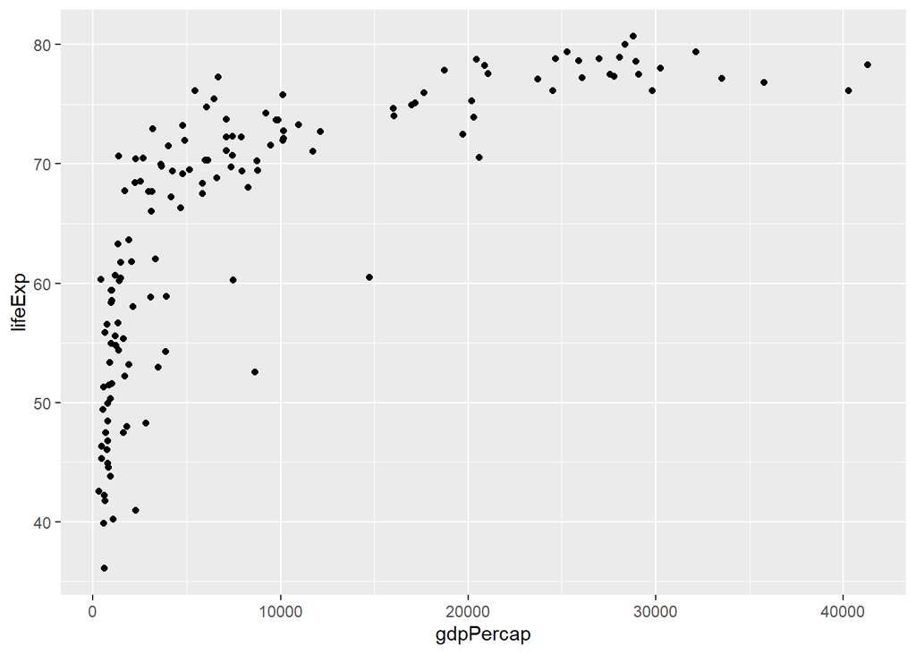

```r
ggplot(data_97_df, aes(x = gdpPercap, y = lifeExp)) + # Contents of the graph
  geom_point()                                        # Type of graph
```

Seems like my hypothesis was correct (for the year 1997, at least).

I know that each data point in the above scatter plot is associated with a country, but which continent is each point associated with?

I would like for my graph to show me the continent associated with each point by assigning a color to each continent, and then coloring its corresponding data points accordingly.

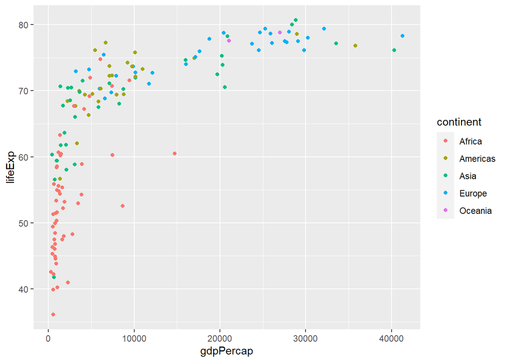

```r
ggplot(data_97_df, aes(x = gdpPercap,
                       y = lifeExp,
                       color = continent)) +
  geom_point()
```

Great! But I’m still not quite happy with the above graph.

The points look a little too small.

We can modify the properties of the plot inside of `geom_point`.

To change point size, we can simply set `size = x`, where `x` is some numeric value.

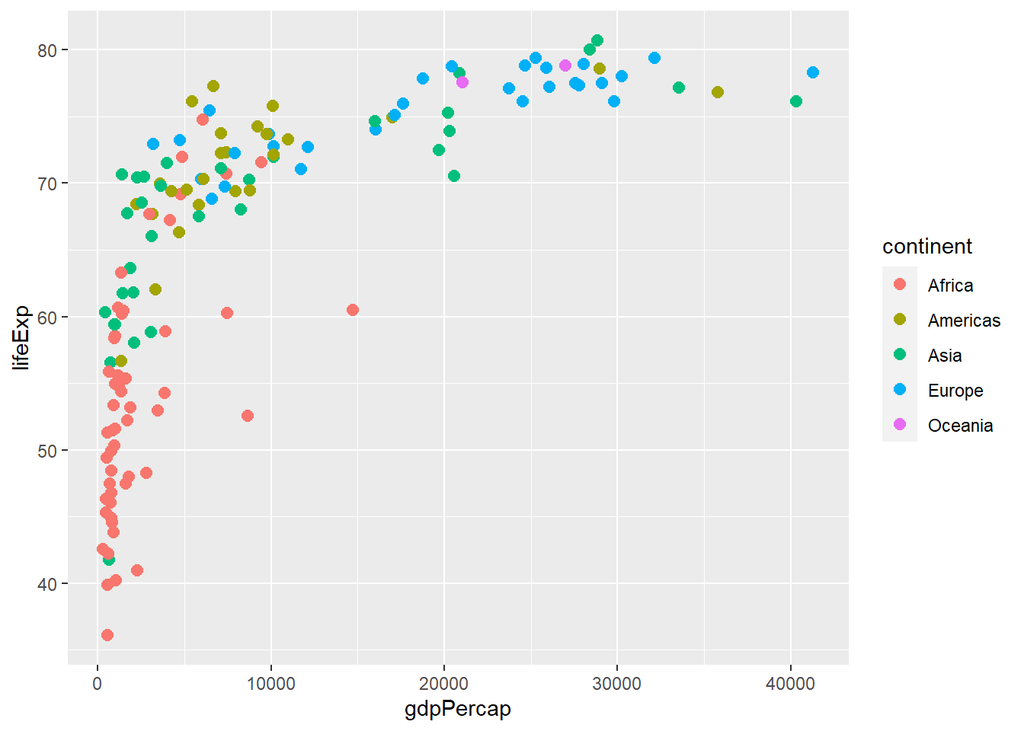

```r
ggplot(data_97_df, aes(x = gdpPercap,
                       y = lifeExp,
                       color = continent)) +
  geom_point(size = 2.5)
```

Let’s also add a title using `ggtitle()`, as well as axis and legend labels using `labs()`.

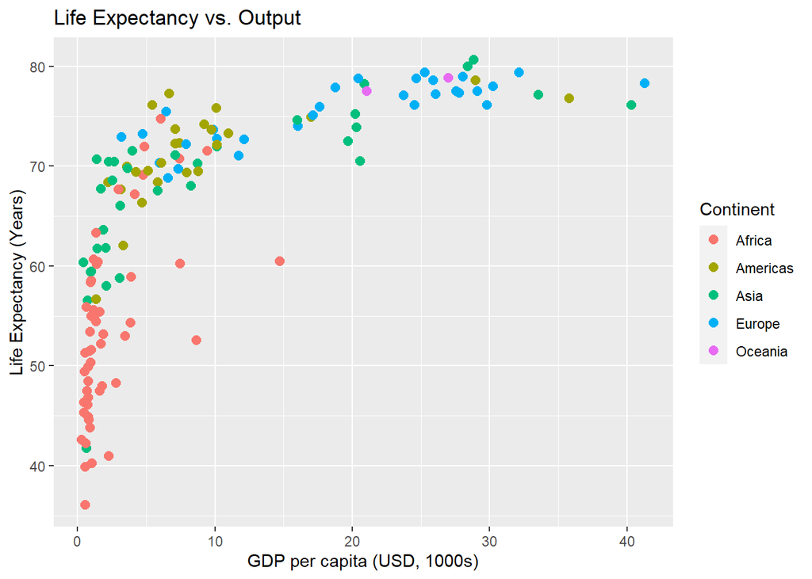

```r
ggplot(data_97_df, aes(x = gdpPercap/1000,
                       y = lifeExp,
                       color = continent)) +
  geom_point(size = 2.5) +
  ggtitle("Life Expectancy vs. Output") +
  labs(x = "GDP per capita (USD, 1000s)",
       y = "Life Expectancy (Years)",
       color = "Continent")
```

Lastly, we can manually set the intervals of the x and y axes using `xlim()` and `ylim()`, respectively.

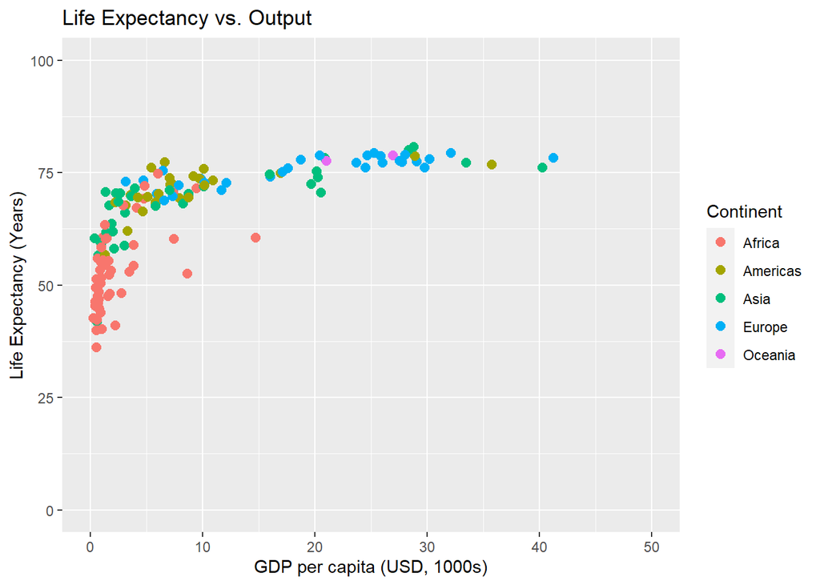

```r
  ggplot(data_97_df, aes(x = gdpPercap/1000,
                         y = lifeExp,
                         color = continent)) +
    geom_point(size = 2.5) +
    ggtitle("Life Expectancy vs. Output") +
    labs(x = "GDP per capita (USD, 1000s)",
         y = "Life Expectancy (Years)",
         color = "Continent") +
    ylim(0,100) +
    xlim(0,50)
```

### Line Plots

Now let’s move on to line plots.

Line plots are often used to visualize the changes in a variable over time.

Suppose I am interested in the average GDP per capita of each continent for each year in my `gapminder` sample – I can use `group_by()` and `summarize()` to obtain this type of aggregated data from the raw country-level data.

```r
continent_allyears_df <- gapminder %>%
                          group_by(year, continent) %>%
                          summarize(avgGDPPercap = mean(gdpPercap))

continent_allyears_df
```

```
## # A tibble: 60 x 3
## # Groups:   year [12]
##     year continent avgGDPPercap
##    <int> <fct>            <dbl>
##  1  1952 Africa           1253.
##  2  1952 Americas         4079.
##  3  1952 Asia             5195.
##  4  1952 Europe           5661.
##  5  1952 Oceania         10298.
##  6  1957 Africa           1385.
##  7  1957 Americas         4616.
##  8  1957 Asia             5788.
##  9  1957 Europe           6963.
## 10  1957 Oceania         11599.
## # ... with 50 more rows
```

I can now create a line graph of my continent-level data, in which the x-axis represents time and the y-axis represents the average GDP per capita in 1000s of USD.

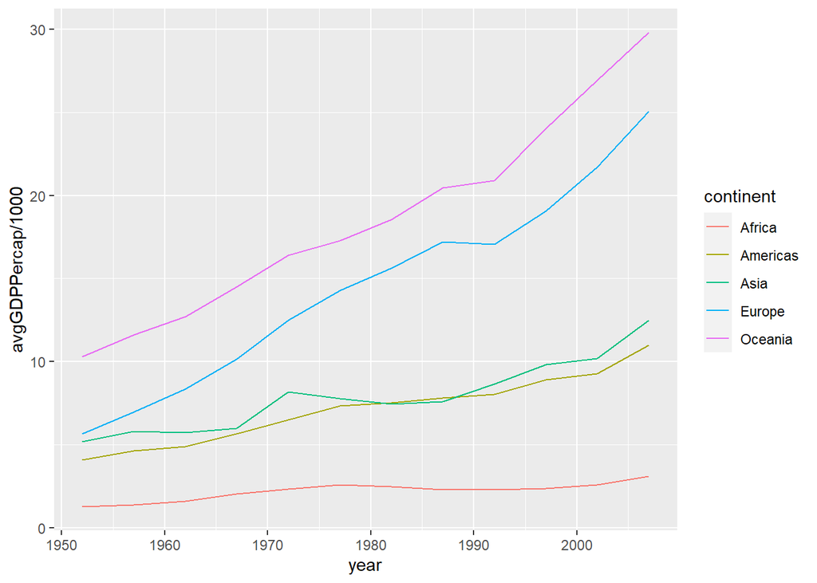

```r
ggplot(continent_allyears_df,
        aes(x = year,
            y = avgGDPPercap/1000,
            color = continent)) +
    geom_line()
```

We can improve the plot by making the lines thicker and adding title, axis, and legend labels.

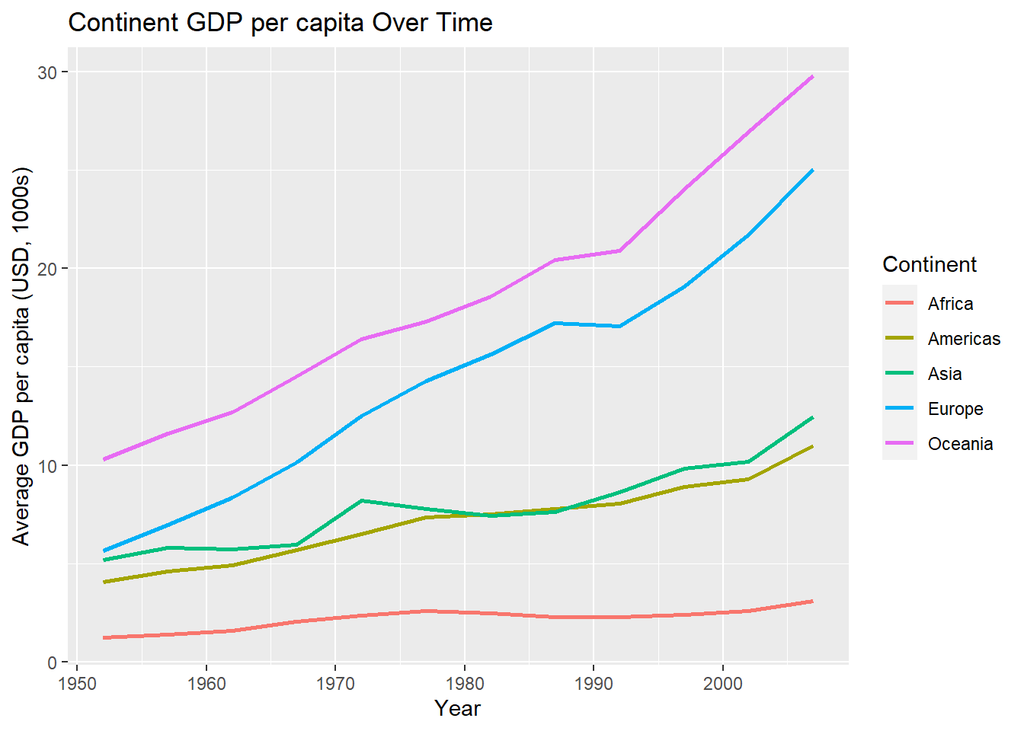

```r
ggplot(continent_allyears_df,
        aes(x = year,
            y = avgGDPPercap/1000,
            color = continent)) +
    geom_line(size = 1) +
    ggtitle("Continent GDP per capita Over Time") +
    labs(x = "Year",
         y = "Average GDP per capita (USD, 1000s)",
         color = "Continent")
```

The may further improve the plot by getting rid of excess empty intervals on the x-axis.

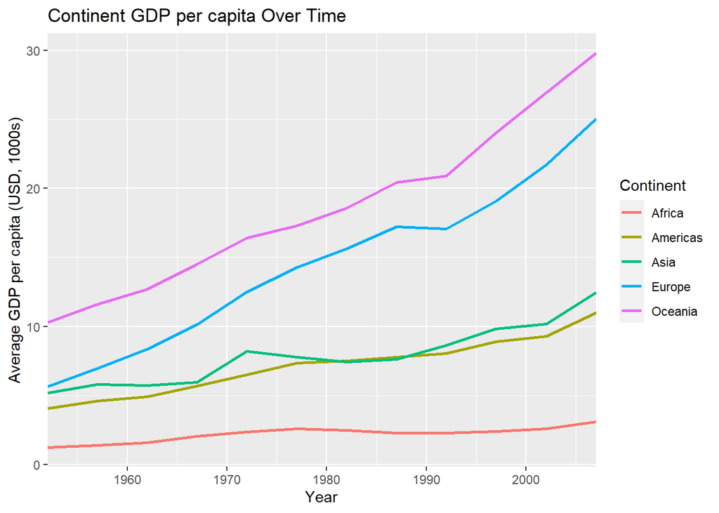

```r
ggplot(continent_allyears_df,
        aes(x = year, y = avgGDPPercap/1000, color = continent)) +
    geom_line(size = 1) +
    ggtitle("Continent GDP per capita Over Time") +
    labs(x = "Year",
         y = "Average GDP per capita (USD, 1000s)",
         color = "Continent") +
    scale_x_continuous(expand = c(0,0))
```

### Histograms

Sometimes we want to check the distributions of variables within our sample – to do so we may use histograms.

Suppose we’re interested in checking the distribution of life expectancy in a subsample of `gapminder` containing observations from only the years 1957 and 2007.

```r
data_57_97_df <- gapminder %>%
                  filter(year %in% c(1957,2007))

data_57_97_df
```

```
## # A tibble: 284 x 6
##    country     continent  year lifeExp      pop gdpPercap
##    <fct>       <fct>     <int>   <dbl>    <int>     <dbl>
##  1 Afghanistan Asia       1957    30.3  9240934      821.
##  2 Afghanistan Asia       2007    43.8 31889923      975.
##  3 Albania     Europe     1957    59.3  1476505     1942.
##  4 Albania     Europe     2007    76.4  3600523     5937.
##  5 Algeria     Africa     1957    45.7 10270856     3014.
##  6 Algeria     Africa     2007    72.3 33333216     6223.
##  7 Angola      Africa     1957    32.0  4561361     3828.
##  8 Angola      Africa     2007    42.7 12420476     4797.
##  9 Argentina   Americas   1957    64.4 19610538     6857.
## 10 Argentina   Americas   2007    75.3 40301927    12779.
## # ... with 274 more rows
```

The conditional statement `year %in% c(1957,2007)` checks whether for each given observation `year` equals either 1957 or 2007 – if `TRUE`, then `filter()` keeps these observations.

We may now plot a simple histogram of `lifeExp` using this newly-constructed subsample of `gapminder`.

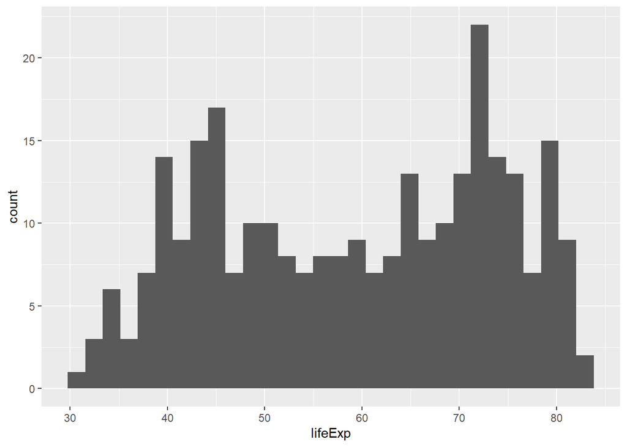

```r
ggplot(data_57_97_df, aes(lifeExp)) +
    geom_histogram()
```

Add title and axis labels:

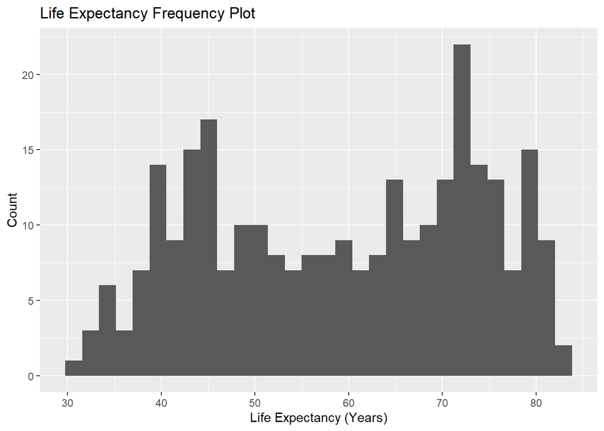

```r
ggplot(data_57_97_df, aes(lifeExp)) +
    geom_histogram() +
    ggtitle("Life Expectancy Frequency Plot") +
    labs(x = "Life Expectancy (Years)",
         y = "Count")
```

Intuitively, the distribution of `lifeExp` in this subsample is bimodal.

Let’s group the observations in our histogram by year:

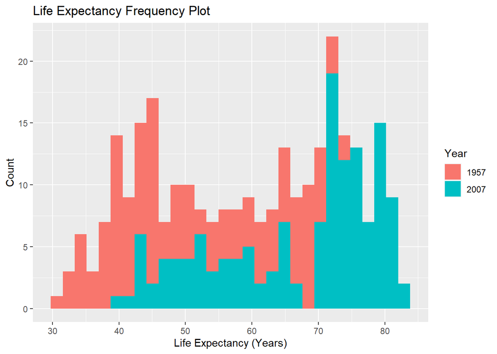

```r
ggplot(data_57_97_df, aes(lifeExp, fill = factor(year))) +
    geom_histogram() +
    ggtitle("Life Expectancy Frequency Plot") +
    labs(x = "Life Expectancy (Years)",
         y = "Count",
         fill = "Year")
```

Perhaps we would like to make the bins wider:

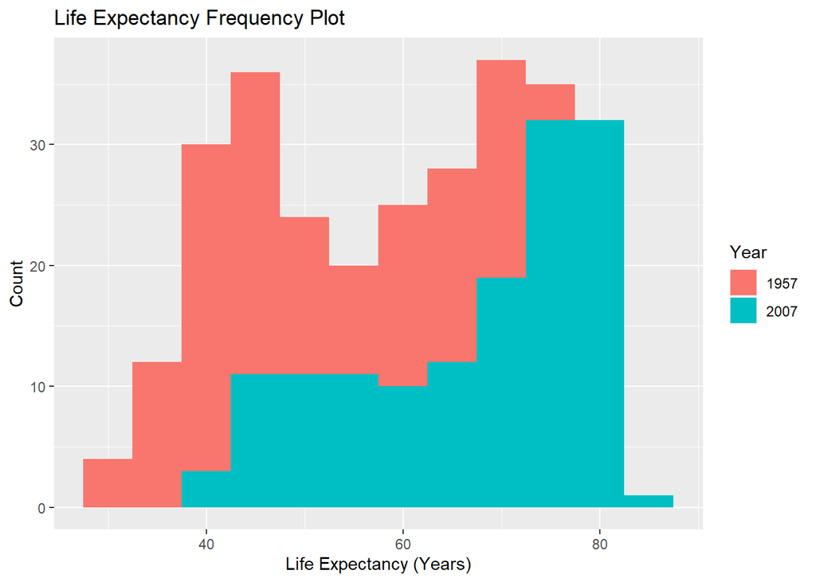

```r
ggplot(data_57_97_df, aes(lifeExp, fill = factor(year))) +
    geom_histogram(binwidth = 5) +
    ggtitle("Life Expectancy Frequency Plot") +
    labs(x = "Life Expectancy (Years)",
         y = "Count",
         fill = "Year")
```

Instead of stacking the two groups of data on top of each other, we might instead like to give each group a separate bar per bin:

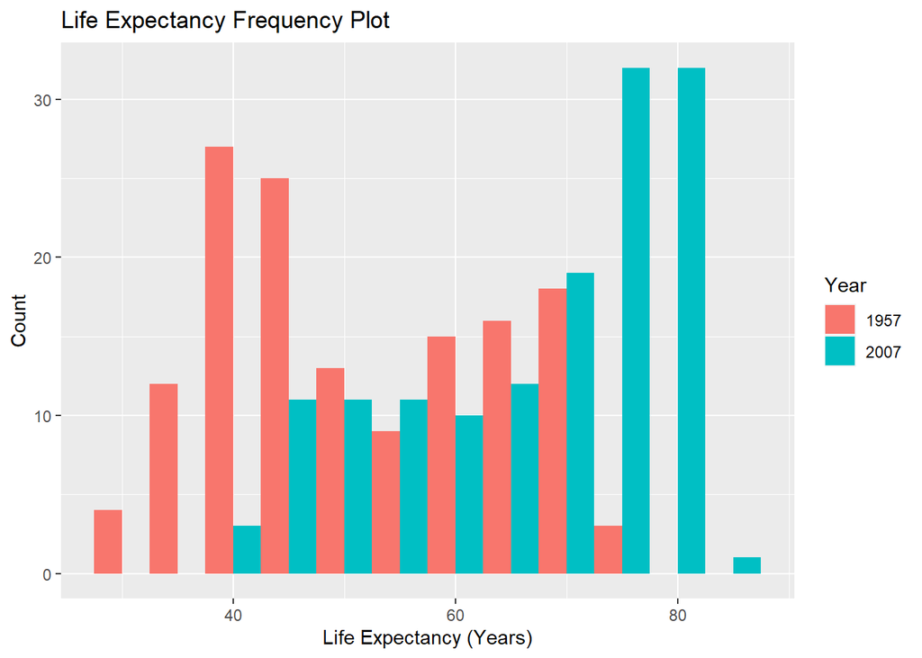

```r
ggplot(data_57_97_df, aes(lifeExp, fill = factor(year))) +
    geom_histogram( binwidth = 5,
                    position = "dodge") +
    ggtitle("Life Expectancy Frequency Plot") +
    labs(x = "Life Expectancy (Years)",
         y = "Count",
         fill = "Year")
```